# R Notebook

libraries

```r
library(mlbench)
library(dplyr)
library(lubridate)
library(ggplot2)
library(factoextra)
library(sets)
library(ggcorrplot)
library(caret)
library(car)
```

Data description:

crim per capita crime rate by town zn proportion of residential land zoned for lots over 25,000 sq.ft indus proportion of non-retail business acres per town chas Charles River dummy variable (= 1 if tract bounds river; 0 otherwise) nox nitric oxides concentration (parts per 10 million) rm average number of rooms per dwelling age proportion of owner-occupied units built prior to 1940 dis weighted distances to five Boston employment centres rad index of accessibility to radial highways tax full-value property-tax rate per USD 10,000 ptratio pupil-teacher ratio by town b 1000(B - 0.63)^2 where B is the proportion of blacks by town lstat percentage of lower status of the population medv median value of owner-occupied homes in USD 1000’s cmedv corrected median value of owner-occupied homes in USD 1000’s town name of town tract census tract lon longitude of census tract lat latitude of census tract

```r
data(BostonHousing2)
```

Check if there is any missing value from data

```r
s = 0
for(i in BostonHousing2){
  if(is.null(i)){
    s = s + 1
  }
}
print(paste("Missing values: ", s))
```

```
[1] "Missing values:  0"
```

Density plots

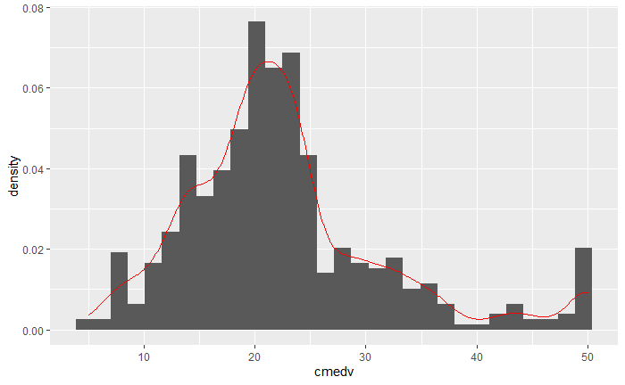

```r
ggplot(BostonHousing2, aes(x = cmedv)) + geom_histogram(bins = 30, aes(y = stat(density))) + geom_density(col="red")
```

Create a variable with all values in numeric type

```r
bostonHousingAllNumeric = BostonHousing2

bostonHousingAllNumeric$town = as.numeric(bostonHousingAllNumeric$town)
bostonHousingAllNumeric$chas = as.numeric(bostonHousingAllNumeric$chas)

bostonHousingAllNumeric
```

|  | town | tract | lon | lat | medv | cmedv | crim | zn | indus | chas | nox | rm | age | dis | rad | tax | ptratio | b | lstat |
| --- | --- | --- | --- | --- | --- | --- | --- | --- | --- | --- | --- | --- | --- | --- | --- | --- | --- | --- | --- |
| 1 | 54 | 2011 | -70.9550 | 42.2550 | 24.0 | 24.0 | 0.00632 | 18.0 | 2.31 | 1 | 0.5380 | 6.575 | 65.2 | 4.0900 | 1 | 296 | 15.3 | 396.90 | 4.98 |
| 2 | 77 | 2021 | -70.9500 | 42.2875 | 21.6 | 21.6 | 0.02731 | 0.0 | 7.07 | 1 | 0.4690 | 6.421 | 78.9 | 4.9671 | 2 | 242 | 17.8 | 396.90 | 9.14 |
| 3 | 77 | 2022 | -70.9360 | 42.2830 | 34.7 | 34.7 | 0.02729 | 0.0 | 7.07 | 1 | 0.4690 | 7.185 | 61.1 | 4.9671 | 2 | 242 | 17.8 | 392.83 | 4.03 |
| 4 | 46 | 2031 | -70.9280 | 42.2930 | 33.4 | 33.4 | 0.03237 | 0.0 | 2.18 | 1 | 0.4580 | 6.998 | 45.8 | 6.0622 | 3 | 222 | 18.7 | 394.63 | 2.94 |
| 5 | 46 | 2032 | -70.9220 | 42.2980 | 36.2 | 36.2 | 0.06905 | 0.0 | 2.18 | 1 | 0.4580 | 7.147 | 54.2 | 6.0622 | 3 | 222 | 18.7 | 396.90 | 5.33 |
| 6 | 46 | 2033 | -70.9165 | 42.3040 | 28.7 | 28.7 | 0.02985 | 0.0 | 2.18 | 1 | 0.4580 | 6.430 | 58.7 | 6.0622 | 3 | 222 | 18.7 | 394.12 | 5.21 |
| 7 | 69 | 2041 | -70.9360 | 42.2970 | 22.9 | 22.9 | 0.08829 | 12.5 | 7.87 | 1 | 0.5240 | 6.012 | 66.6 | 5.5605 | 5 | 311 | 15.2 | 395.60 | 12.43 |
| 8 | 69 | 2042 | -70.9375 | 42.3100 | 27.1 | 22.1 | 0.14455 | 12.5 | 7.87 | 1 | 0.5240 | 6.172 | 96.1 | 5.9505 | 5 | 311 | 15.2 | 396.90 | 19.15 |
| 9 | 69 | 2043 | -70.9330 | 42.3120 | 16.5 | 16.5 | 0.21124 | 12.5 | 7.87 | 1 | 0.5240 | 5.631 | 100.0 | 6.0821 | 5 | 311 | 15.2 | 386.63 | 29.93 |
| 10 | 69 | 2044 | -70.9290 | 42.3160 | 18.9 | 18.9 | 0.17004 | 12.5 | 7.87 | 1 | 0.5240 | 6.004 | 85.9 | 6.5921 | 5 | 311 | 15.2 | 386.71 | 17.10 |

[output cut: 496 more lines]

Correlation Matrix

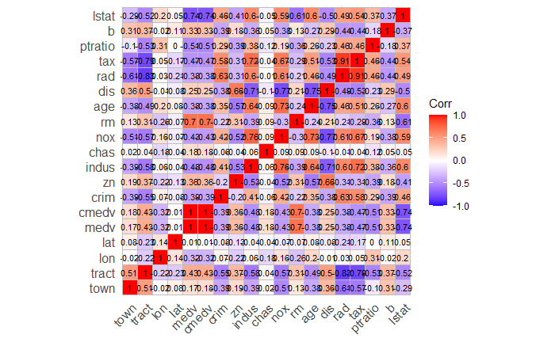

```r
ggcorrplot(cor(bostonHousingAllNumeric), lab = TRUE, lab_size = 3)
```

From the correlation matrix we can infer that rm and lstat are the best variables to apply linear regression

Scatter Plot for rm

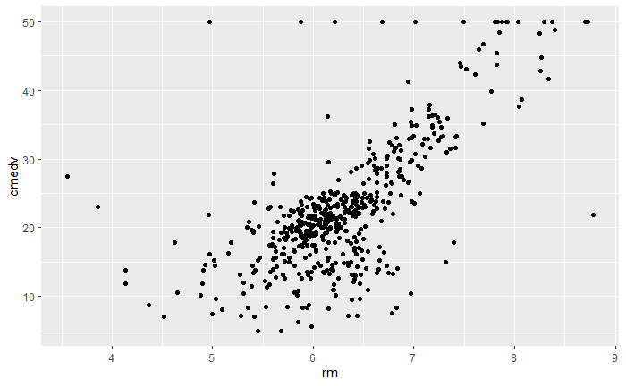

```r
ggplot(bostonHousingAllNumeric, aes(x = rm, y = cmedv)) + geom_point()
```

Scatter plot for lstat

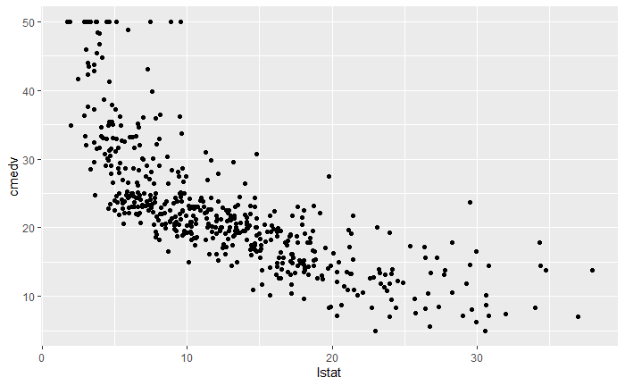

```r
ggplot(bostonHousingAllNumeric, aes(x = lstat, y = cmedv)) + geom_point()
```

Split training and testing data

```r
trainingTestingData = data.frame(rm = BostonHousing2$rm,
                                 lstat = BostonHousing2$lstat, cmedv = BostonHousing2$cmedv)

trainTestIndex = createDataPartition(x$rm, p = 0.8, list = FALSE)
```

```r
print(trainingTestingData[trainTestIndex,])
```

|  | rm | lstat | cmedv |
| --- | --- | --- | --- |
| 2 | 6.421 | 9.14 | 21.6 |
| 3 | 7.185 | 4.03 | 34.7 |
| 4 | 6.998 | 2.94 | 33.4 |
| 5 | 7.147 | 5.33 | 36.2 |
| 6 | 6.430 | 5.21 | 28.7 |
| 8 | 6.172 | 19.15 | 22.1 |
| 9 | 5.631 | 29.93 | 16.5 |
| 10 | 6.004 | 17.10 | 18.9 |
| 12 | 6.009 | 13.27 | 18.9 |
| 13 | 5.889 | 15.71 | 21.7 |

[output cut: 396 more lines]

```r
print(trainingTestingData[-trainTestIndex,])
```

|  | rm | lstat | cmedv |
| --- | --- | --- | --- |
| 1 | 6.575 | 4.98 | 24.0 |
| 7 | 6.012 | 12.43 | 22.9 |
| 11 | 6.377 | 20.45 | 15.0 |
| 15 | 6.096 | 10.26 | 18.2 |
| 22 | 5.965 | 13.83 | 19.6 |
| 23 | 6.142 | 18.72 | 15.2 |
| 34 | 5.701 | 18.35 | 13.1 |
| 35 | 6.096 | 20.34 | 13.5 |
| 40 | 6.595 | 4.32 | 30.8 |
| 41 | 7.024 | 1.98 | 34.9 |

[output cut: 90 more lines]

Make the linear regression model

```r
linearRegression = lm(formula = cmedv ~ rm + lstat, data = trainingTestingData[trainTestIndex,])
summary(linearRegression)
```

```
Call:
lm(formula = cmedv ~ rm + lstat, data = trainingTestingData[trainTestIndex,
    ])

Residuals:
     Min       1Q   Median       3Q      Max
-18.9107  -3.4673  -0.9585   1.9294  28.8003

Coefficients:
            Estimate Std. Error t value Pr(>|t|)
(Intercept) -4.00619    3.57066  -1.122    0.263
rm           5.47452    0.49763  11.001   <2e-16 ***
lstat       -0.61425    0.04912 -12.504   <2e-16 ***
---
Signif. codes:  0 ‘***’ 0.001 ‘**’ 0.01 ‘*’ 0.05 ‘.’ 0.1 ‘ ’ 1

Residual standard error: 5.513 on 403 degrees of freedom
Multiple R-squared:  0.6525,    Adjusted R-squared:  0.6508
F-statistic: 378.3 on 2 and 403 DF,  p-value: < 2.2e-16
```

print line for the linear regression model

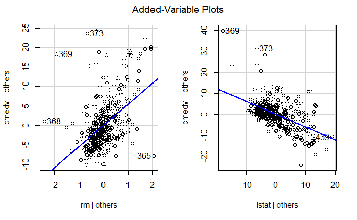

```r
avPlots(linearRegression)
```

Predict on test set

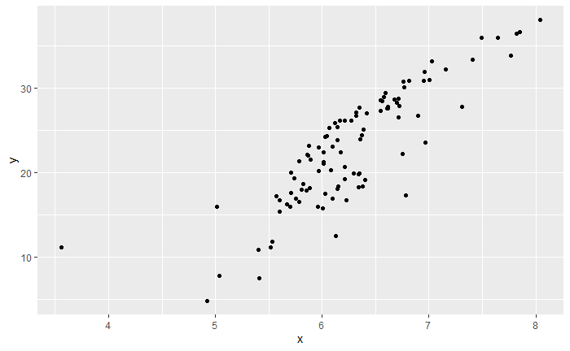

```r
testResults = predict(linearRegression, trainingTestingData[-trainTestIndex,])

ggplot(data.frame(x = trainingTestingData[-trainTestIndex,]$rm, y = testResults),
       aes(x = x, y = y)) + geom_point()
```